# Dimensionality reduction techniques

```r
library(MASS)
library(tidyverse)
library(ggplot2)
library(GGally)
library(corrplot)
library(FactoMineR)

#loading the data
human <- read.table("data/human.csv", header = TRUE, sep = ",", row.names = 1)
```

## Data overview

```r
# summaries
summary(human)
```

```
##     Edu2.FM          Labo.FM          Edu.Exp         Life.Exp
##  Min.   :0.1717   Min.   :0.1857   Min.   : 5.40   Min.   :49.00
##  1st Qu.:0.7264   1st Qu.:0.5984   1st Qu.:11.25   1st Qu.:66.30
##  Median :0.9375   Median :0.7535   Median :13.50   Median :74.20
##  Mean   :0.8529   Mean   :0.7074   Mean   :13.18   Mean   :71.65
##  3rd Qu.:0.9968   3rd Qu.:0.8535   3rd Qu.:15.20   3rd Qu.:77.25
##  Max.   :1.4967   Max.   :1.0380   Max.   :20.20   Max.   :83.50
##       GNI            Mat.Mor         Ado.Birth         Parli.F
##  Min.   :  2.00   Min.   :   1.0   Min.   :  0.60   Min.   : 0.00
##  1st Qu.: 53.50   1st Qu.:  11.5   1st Qu.: 12.65   1st Qu.:12.40
##  Median : 99.00   Median :  49.0   Median : 33.60   Median :19.30
##  Mean   : 98.73   Mean   : 149.1   Mean   : 47.16   Mean   :20.91
##  3rd Qu.:143.50   3rd Qu.: 190.0   3rd Qu.: 71.95   3rd Qu.:27.95
##  Max.   :194.00   Max.   :1100.0   Max.   :204.80   Max.   :57.50
```

We can see that health related variebles have huge differences between extremes and IQR. That meens there is big difference between developed and the developing countries. And considering variable Parli.F, the minimum is zero, meening there is at least one country which does not allow women to be in the parliment.

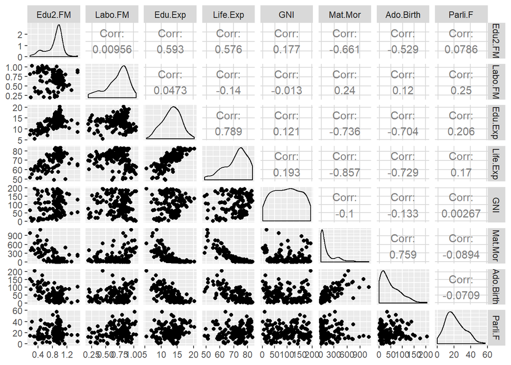

```r
#graphical analysis
ggpairs(human)
```

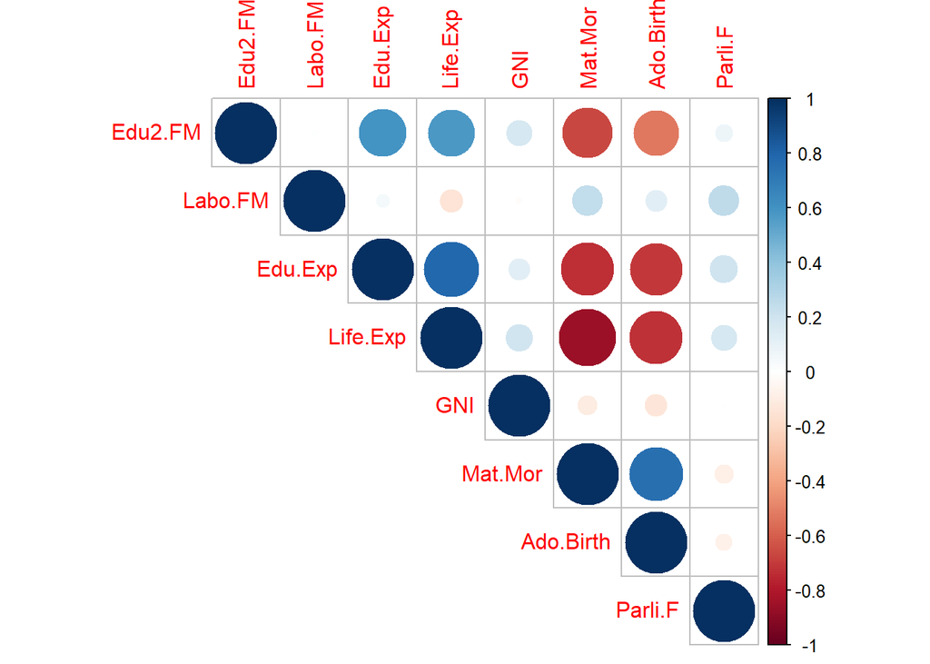

```r
# relationships among variables
cor(human) %>% corrplot(type = "upper")
```

There is a very strong negative correlation between edu.exp, life.exp & mat.mor, ado.bir (ado.birt and mat.mor are strongly positively correlated). That makes sense. On the other hand, there is a strong correlation between edu.exp and life.exp, so the more people go to school, the longer are they expected to live.

## Principal component analysis

```r
# analysis on the not scaled data
pca_human <- prcomp(human)
summary(pca_human)
```

```
## Importance of components:
##                             PC1      PC2      PC3      PC4     PC5     PC6
## Standard deviation     214.3202 54.48589 26.38141 11.47911 4.06687 1.60671
## Proportion of Variance   0.9233  0.05967  0.01399  0.00265 0.00033 0.00005
## Cumulative Proportion    0.9233  0.98298  0.99697  0.99961 0.99995 1.00000
##                           PC7    PC8
## Standard deviation     0.1905 0.1587
## Proportion of Variance 0.0000 0.0000
## Cumulative Proportion  1.0000 1.0000
```

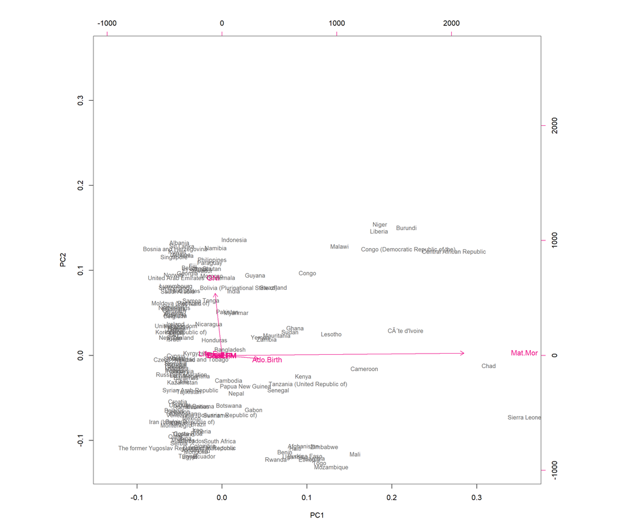

```r
biplot(pca_human, choices = 1:2, cex = c(0.8, 1), col = c("grey40", "deeppink2"))
```

```r
# analysis on the scaled data
scaled <- scale(human)
pca_scaled <- prcomp(scaled)
summary(pca_scaled)
```

```
## Importance of components:
##                          PC1    PC2    PC3     PC4     PC5     PC6     PC7
## Standard deviation     1.966 1.1388 0.9900 0.86598 0.69931 0.54001 0.46701
## Proportion of Variance 0.483 0.1621 0.1225 0.09374 0.06113 0.03645 0.02726
## Cumulative Proportion  0.483 0.6452 0.7677 0.86140 0.92253 0.95898 0.98625
##                            PC8
## Standard deviation     0.33172
## Proportion of Variance 0.01375
## Cumulative Proportion  1.00000
```

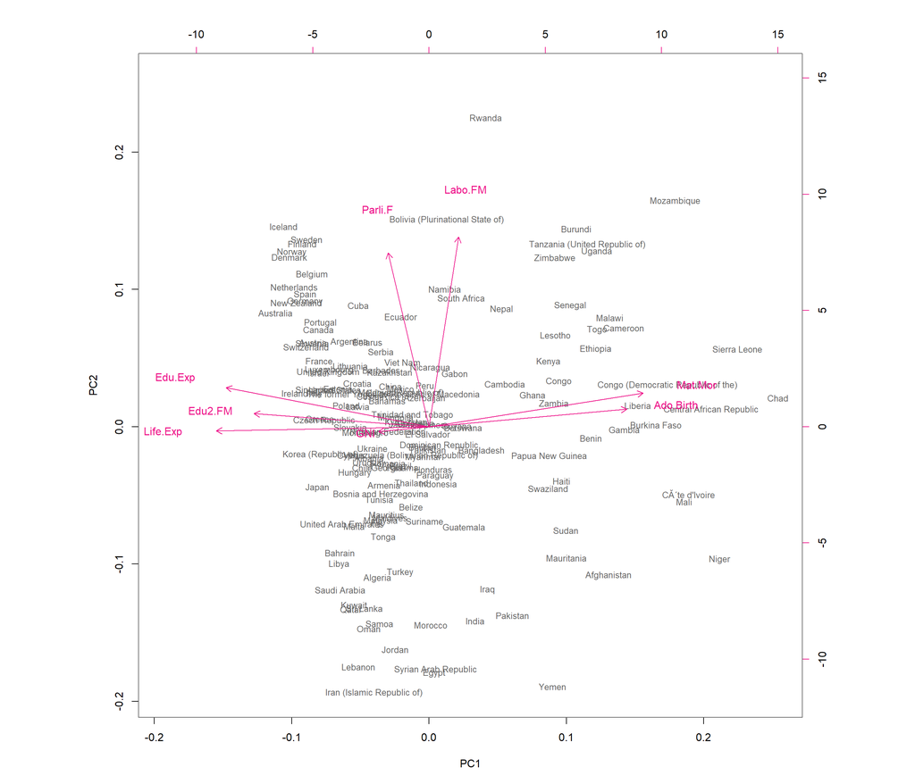

```r
biplot(pca_scaled, choices = 1:2, cex = c(0.8, 1), col = c("grey40", "deeppink2"))
```

The results are different since the non-scaled data have a wide range of values. The scaled data are scaled to normal distribution, meaning the mean value is 0, and the other indicators in summary (min, max, median…) have a p-value associated with them - that gives us likelihood of observing value at least as extreme. The scaled biplot is better to uncover relationships between features and components. The graphical representation is more equally distributed in the scaled data.

The non-scaled data is almost undecipherable. Nevertheless, it shows us a strong correlation between mat.mor and PC1 and a strong correlation between GNI and PC2. Length of these two features also suggest their very high standard deviation. Mat.mor and GNI are close to orthogonal to each other, that means there is almost no correlation between these two features.

## Multiple Correspondence Analysis

```r
# loading data
data("tea")
```

```r
# exploring the data
dim(tea)
```

```
## [1] 300  36
```

```r
str(tea)
```

```
## 'data.frame':    300 obs. of  36 variables:
##  $ breakfast       : Factor w/ 2 levels "breakfast","Not.breakfast": 1 1 2 2 1 2 1 2 1 1 ...
##  $ tea.time        : Factor w/ 2 levels "Not.tea time",..: 1 1 2 1 1 1 2 2 2 1 ...
##  $ evening         : Factor w/ 2 levels "evening","Not.evening": 2 2 1 2 1 2 2 1 2 1 ...
##  $ lunch           : Factor w/ 2 levels "lunch","Not.lunch": 2 2 2 2 2 2 2 2 2 2 ...
##  $ dinner          : Factor w/ 2 levels "dinner","Not.dinner": 2 2 1 1 2 1 2 2 2 2 ...
##  $ always          : Factor w/ 2 levels "always","Not.always": 2 2 2 2 1 2 2 2 2 2 ...
##  $ home            : Factor w/ 2 levels "home","Not.home": 1 1 1 1 1 1 1 1 1 1 ...
##  $ work            : Factor w/ 2 levels "Not.work","work": 1 1 2 1 1 1 1 1 1 1 ...
##  $ tearoom         : Factor w/ 2 levels "Not.tearoom",..: 1 1 1 1 1 1 1 1 1 2 ...
##  $ friends         : Factor w/ 2 levels "friends","Not.friends": 2 2 1 2 2 2 1 2 2 2 ...
##  $ resto           : Factor w/ 2 levels "Not.resto","resto": 1 1 2 1 1 1 1 1 1 1 ...
##  $ pub             : Factor w/ 2 levels "Not.pub","pub": 1 1 1 1 1 1 1 1 1 1 ...
##  $ Tea             : Factor w/ 3 levels "black","Earl Grey",..: 1 1 2 2 2 2 2 1 2 1 ...
##  $ How             : Factor w/ 4 levels "alone","lemon",..: 1 3 1 1 1 1 1 3 3 1 ...
```

[output cut: 22 more lines]

There are 300 observations of 36 variables. The data basically covers who, when, where, with whom likes to drink tea.

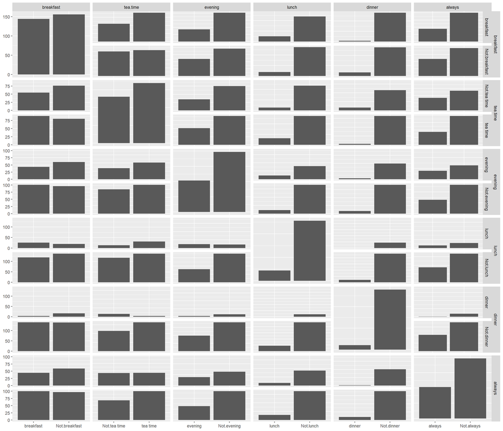

```r
ggpairs(tea[,1:6])
```

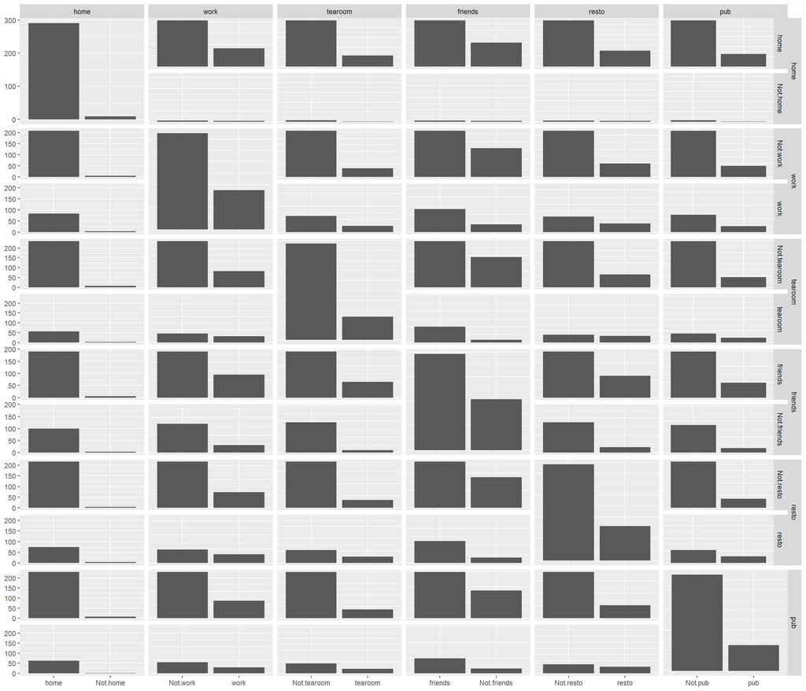

```r
ggpairs(tea[,7:12])
```

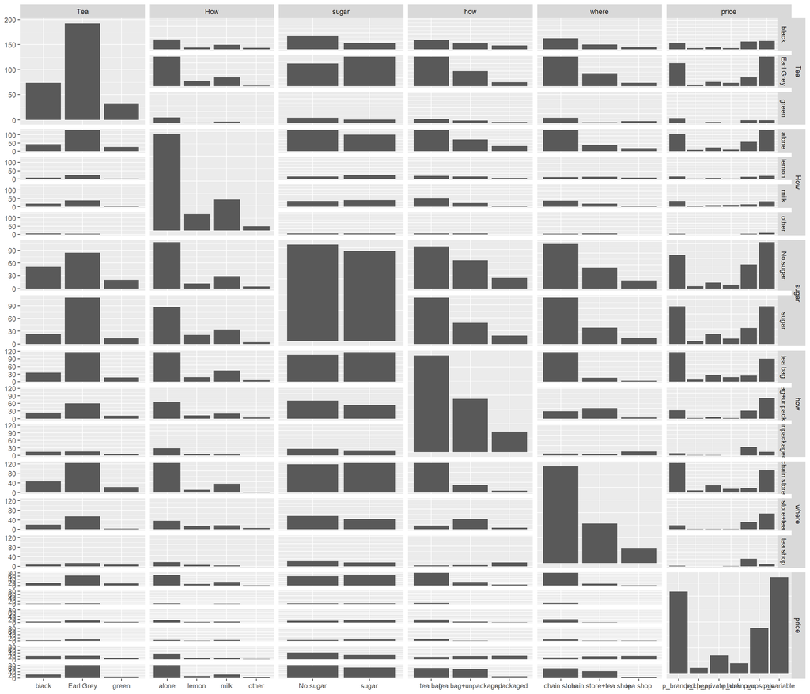

```r
ggpairs(tea[,13:18])
```

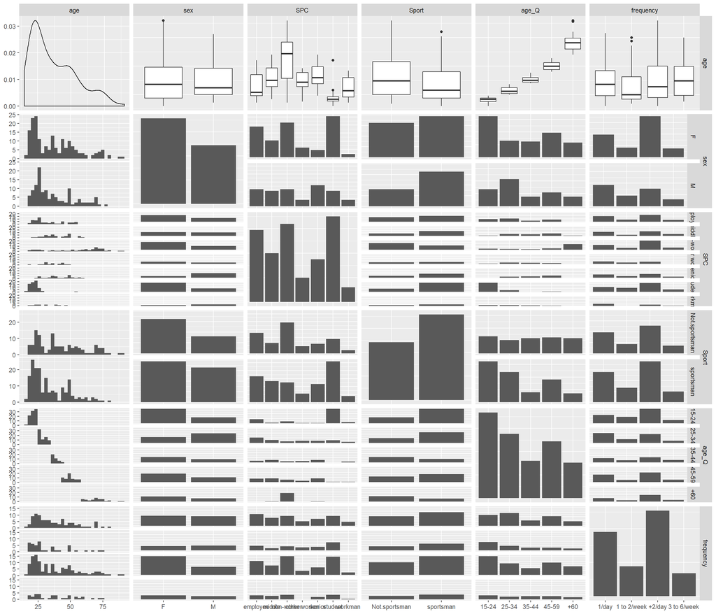

```r
ggpairs(tea[,19:24])
```

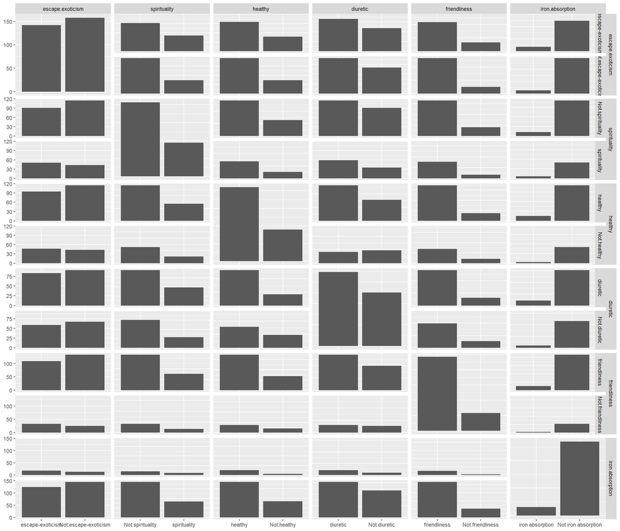

```r
ggpairs(tea[,25:30])
```

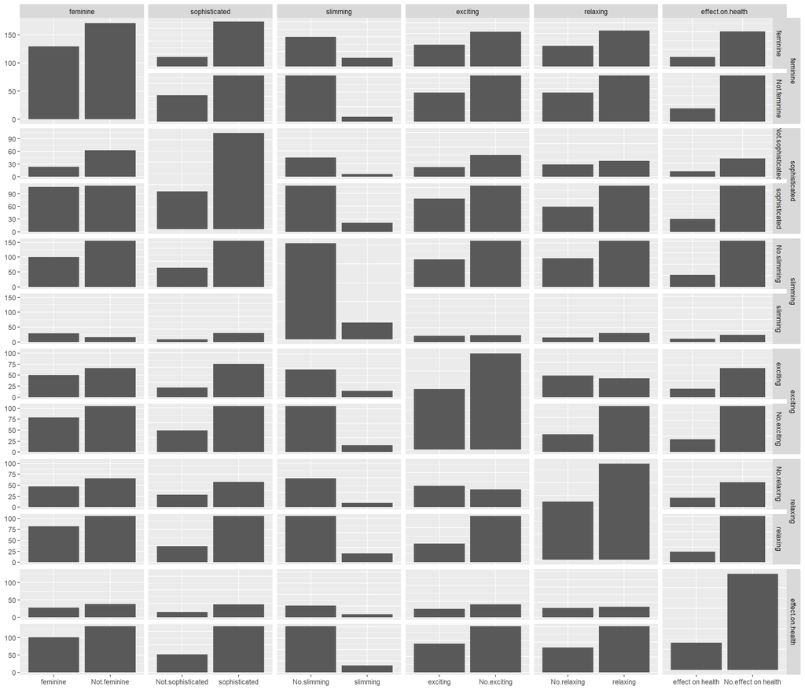

```r
ggpairs(tea[,31:36])
```

We can see distributions of all variables from the graphs above.

```r
# Multiple Correspondence Analysis
# choosing the kolumns to keep
tea_keep <- dplyr::select(tea, one_of(c("Tea", "healthy", "resto", "sugar", "where", "dinner")))
mca <- MCA(tea_keep, graph = FALSE)
summary(mca)
```

```
##
## Call:
## MCA(X = tea_keep, graph = FALSE)
##
##
## Eigenvalues
##                        Dim.1   Dim.2   Dim.3   Dim.4   Dim.5   Dim.6
## Variance               0.245   0.214   0.180   0.170   0.147   0.137
## % of var.             18.392  16.034  13.472  12.728  11.054  10.249
## Cumulative % of var.  18.392  34.427  47.898  60.627  71.681  81.930
##                        Dim.7   Dim.8
## Variance               0.124   0.117
## % of var.              9.271   8.799
## Cumulative % of var.  91.201 100.000
##
## Individuals (the 10 first)
##                Dim.1    ctr   cos2    Dim.2    ctr   cos2    Dim.3    ctr
## 1           |  0.077  0.008  0.006 |  0.146  0.033  0.023 | -0.412  0.315
## 2           |  0.122  0.020  0.017 |  0.685  0.731  0.520 | -0.415  0.319
## 3           |  0.093  0.012  0.003 | -0.087  0.012  0.002 |  0.913  1.548
## 4           |  0.535  0.389  0.106 | -0.722  0.813  0.192 |  0.660  0.808
## 5           | -0.088  0.011  0.010 | -0.178  0.050  0.040 | -0.312  0.181
## 6           |  0.580  0.458  0.125 | -0.183  0.052  0.012 |  0.657  0.801
## 7           |  0.081  0.009  0.013 |  0.099  0.015  0.020 | -0.304  0.171
## 8           |  0.122  0.020  0.017 |  0.685  0.731  0.520 | -0.415  0.319
## 9           | -0.328  0.146  0.091 |  0.043  0.003  0.002 |  0.263  0.128
## 10          | -0.117  0.019  0.011 |  0.906  1.280  0.640 |  0.160  0.048
##               cos2
## 1            0.184 |
## 2            0.190 |
## 3            0.270 |
## 4            0.161 |
## 5            0.121 |
## 6            0.161 |
## 7            0.190 |
## 8            0.190 |
## 9            0.058 |
## 10           0.020 |
##
## Categories (the 10 first)
```

[output cut: 16 more lines]

```
## Not.healthy  -6.109 |  -0.014   0.006   0.000  -0.162 |
## Not.resto    -2.031 |  -0.171   2.010   0.082  -4.959 |
## resto         2.031 |   0.480   5.623   0.082   4.959 |
## No.sugar     12.922 |  -0.003   0.000   0.000  -0.057 |
## sugar       -12.922 |   0.003   0.001   0.000   0.057 |
## chain store  -4.370 |  -0.562  18.771   0.562 -12.962 |
##
## Categorical variables (eta2)
##               Dim.1 Dim.2 Dim.3
## Tea         | 0.444 0.475 0.035 |
## healthy     | 0.053 0.125 0.000 |
## resto       | 0.406 0.014 0.082 |
## sugar       | 0.004 0.558 0.000 |
## where       | 0.420 0.071 0.571 |
## dinner      | 0.143 0.040 0.389 |
```

The first dimension explains 18% of the variance in data and the second 16%. That´s not a lot.In categories, the v.test column, if the value is below/above +/- 1.96, we can say that the coordinate is significantly different from zero.In the first dimension, green, resto and Not.resto seem to be the most significant. In the second it is black, Earl grey, No.sugar and sugar. In categorical variables, no variable is particulary close to one so it does not suggest a very strong link between variables and the dimensions.

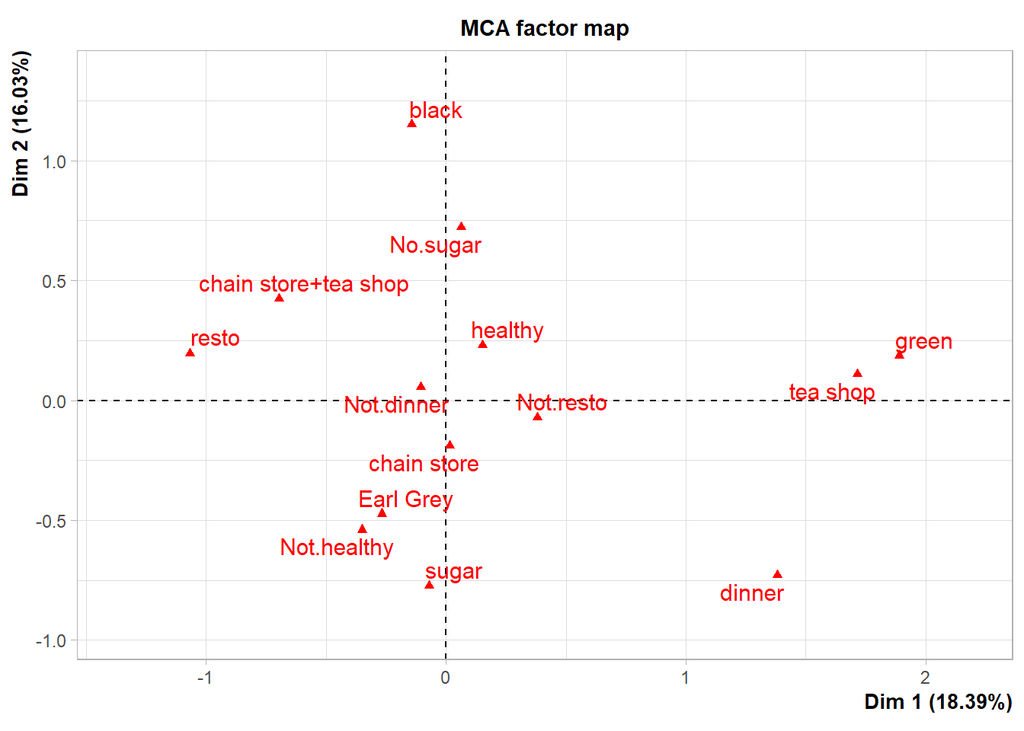

```r
# biplot
plot(mca, invisible=c("ind"))
```

The distance between variable categories gives a measure of their similarity. For instance, earl grey and not.healthy are very similar, so are tea shop and green. Dinner seems to be the most unlike any other.